# DE between covid and control by cell type

Arun Chavan

Started: 2020-09-20  
Last edited: 2020-09-23 10:44:34

```r
library(tidyverse)

# single cell
library(Seurat)

# plotting
library(patchwork)
library(ggthemes)
library(ggrepel)
library(ggforce)

# go enrichment
library(clusterProfiler)
library(org.Hs.eg.db)
```

# 1 Background

Our goal here is to perform differential expression analysis between covid and control samples separately for each annotated cell type in the single cell RNA-seq data.

# 2 Data

We will use the `Seurat` object in which we have saved the cell annotations.

```r
seur <- readRDS("../results/02_annotation/seurat-object_annotated.rds")
```

# 3 Differentialy expressed genes

We will use the “merged” annotations as our celltypes for which to perform DE analysis. For idetifying differentially expressed genes, we will use `Seurat::FindMarkers()`. For this we first have to create a new metadata column with `celltype_covid` and `celltype_control` values, and then we run DE between these two `idents`. This function by dafault uses the Wilcoxon Rank Sum test, which we won’t change. By default this function outputs all genes for which `abs(logFC)` is at least `0.25`, without filtering by p value. This is one bit that we will change—we will output genes that have `abs(logFC) > 0.25` AND `adj_p < 0.05`.

The output of this for each cell type is stored as `.csv` in `results/04_de-genes-by-celltype/files`.

```r
# set up
seur$celltype_covid <- paste(seur$annotation_merged, seur$covid, sep = "_")
Idents(seur) <- seur$celltype_covid
```

```r
# de
de.genes <- list()

for (i in unique(seur$annotation_merged)) {
  de.genes[[i]] <-  FindMarkers(seur,
                                ident.1 = paste0(i, "_covid"),
                                ident.2 = paste0(i, "_cntrl"),
                                assay = "SCT", verbose = FALSE) %>%
    dplyr::filter(p_val_adj < 0.05) %>%
    dplyr::rename(pct.covid = pct.1,
                  pct.cntrl = pct.2)
}
```

```r
# write DE genes to files
for(i in unique(seur$annotation_merged)) {
  write.csv(de.genes[[i]],
            file = paste0("../results/04_de-genes-by-celltype/files/de-genes_", i, ".csv" ),
            row.names = TRUE)
}
```

## 3.1 Number of DE genes by celltype

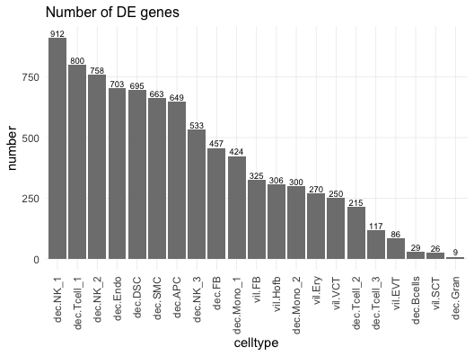

```r
de.number <- lapply(de.genes, nrow) %>% as.data.frame() %>% t() %>% as.data.frame()
colnames(de.number) <- "number"
de.number$celltype <- rownames(de.number)
de.number <- de.number[order(de.number$number, decreasing = TRUE), ]

de.number$celltype <- factor(de.number$celltype, levels = de.number$celltype)

p <- ggplot(data = de.number, aes(x = celltype, y = number, label = number)) +
  geom_bar(stat = "identity", fill = "grey50") +
  geom_text(size = 2.5, vjust = -0.25) +
  ggtitle("Number of DE genes") +
  coord_cartesian(clip = "off") +
  theme_minimal() +
  theme(plot.title = element_text(size = 12),
        panel.grid.minor = element_blank(),
        panel.grid.major = element_line(size = 0.25),
        legend.key.size = unit(0.75, "lines"),
        axis.text.x = element_text(angle = 90, hjust = 1, vjust = 0.5))

ggsave(p, filename = "../results/04_de-genes-by-celltype/plots/number-of-de-genes.pdf", width = 5, height = 3.75, units = "in")

print(p)
```

## 3.2 Mitochondrial UMI

For some cell types a lot of mitochondrial genes are DE between covid and control. It’s possible that those genes are really differentially expressed, but it’s more likely that there is a difference between covid and control samples in terms of quality of cell-prep. We can look at percent mitochondrial UMI in all cell types by covid status to see if this is true.

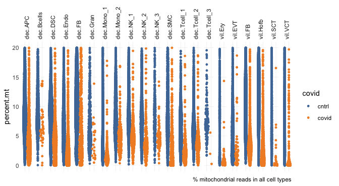

```r
ggplot(data = seur@meta.data, aes(x = covid, y = percent.mt)) +
  geom_sina(aes(color = covid), size = 1, alpha = 1) +
  scale_color_tableau() +
  facet_grid(.~ annotation_merged) +
  labs(caption = "% mitochondrial reads in all cell types") +
  theme_minimal() +
  theme(axis.text.x = element_blank(),
        axis.title.x = element_blank(),
        panel.grid.major = element_line(size = 0.2),
        panel.grid.minor = element_blank(),
        strip.text.x = element_text(angle = 90, hjust = 0, vjust = 0.5))
```

For most cell types there appears to be a difference in the distribution of percent mitochondrial reads between covid and control samples. Covid samples generally have lower % mitochondrial reads. Next, we can plot the absolute value of the difference in percent mitochondrial reads between covid and control against the number of DE genes that are mitochondrial. If the mitochondrial genes in DE analysis are driven by differences in sample quality, we should expect a positive realtionship.

```r
mt <- data.frame(
  celltype = sort(names(de.genes)),
  mt.diff = NA,
  mt.de = NA
)

for(i in mt$celltype) {
  mt$mt.diff[mt$celltype == i] <- abs(
    median(seur$percent.mt[seur$annotation_merged == i & seur$covid == "covid"]) -
      median(seur$percent.mt[seur$annotation_merged == i & seur$covid == "cntrl"])
  )

  mt$mt.de[mt$celltype == i] <- grep("MT-", rownames(de.genes[[i]])) %>% length()
}
```

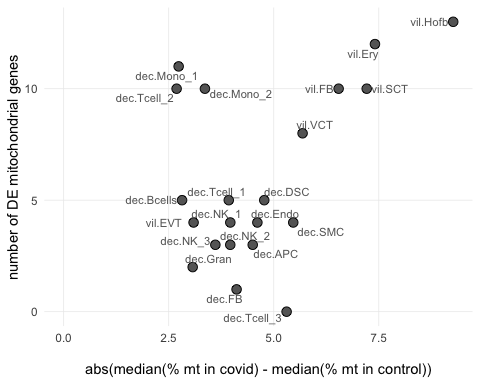

```r
ggplot(data = mt, aes(x = mt.diff, y = mt.de, label = celltype)) +
  geom_point(shape = 21, color = "black", fill = "grey40", size = 3) +
  coord_cartesian(xlim = c(0, NA), ylim = c(0, NA)) +
  geom_text_repel(size = 3, color = "grey40") +
  labs(x = "\nabs(median(% mt in covid) - median(% mt in control))",
       y = "number of DE mitochondrial genes") +
  theme_minimal() +
  theme(panel.grid.major = element_line(size = 0.25),
        panel.grid.minor = element_blank())
```

```r
summary(lm(data = mt, mt.de ~ mt.diff))
```

```
Call:
lm(formula = mt.de ~ mt.diff, data = mt)

Residuals:
    Min      1Q  Median      3Q     Max
-6.6876 -2.3318 -0.4495  2.0607  6.9097

Coefficients:
            Estimate Std. Error t value Pr(>|t|)
(Intercept)    1.323      2.245   0.590   0.5624
mt.diff        1.011      0.451   2.241   0.0371 *
---
Signif. codes:  0 ‘***’ 0.001 ‘**’ 0.01 ‘*’ 0.05 ‘.’ 0.1 ‘ ’ 1

Residual standard error: 3.539 on 19 degrees of freedom
Multiple R-squared:  0.2091,    Adjusted R-squared:  0.1675
F-statistic: 5.024 on 1 and 19 DF,  p-value: 0.03713
```

There is a positive relationship between these two variables, visually as well as statistically. More so for villous cell types. Three decidual cell types—dec.Mono_1, dec.Mono_2, and dec.Tcell_2—have high number of MT DE genes despite low difference in percent MT reads.

We could ignore the mitochondrial genes when interpreting DE results, or we could rerun DE analysis excluding the mitochondrial genes.

# 4 Interferome

Interferome (Rusinova et al. 2012) is a manually curated database of interferon-responsive genes, available at http://www.interferome.org/interferome/home.jspx. The database essentially contains a list of all genes whose expression is affected by interferons, as inferred from various datasets. These datasets include in vitro and in vivo studies from human and mouse. The online interface includes a search function which allows users to input a list of genes, which are searched against the database. The output includes various things including: (1) list of genes from the input that are found in the inferferome database, i.e. there is evidence for these genes to be modulated by interferon, (2) a detailed table with links pointing to the dataset from which the evidence was gathered for each gene, (3) gene ontology enrichment, (4) TF binding site analysis, etc.

I ran the list of DE genes for each of the 21 celltypes through Interferome (`version 2.01`, 2020-09-20) and saved the text output for (1) and (2) from above. I used the following search parameters (all defaults except for narrowing species to *Homo sapiens*)

```
Interferome Type:   Any
Interferome SubType:    Any
Treatment Concentration:    Any
Treatment Time: Any
Vivo/Vitro: Any
Species:    Homo sapiens
System: Any
Organ:  Any
Cell:   Any
Cell Line:  Any
Normal/Abnormal:    Any
Fold Change Up: 2.0
Fold Change Down:   2.0
```

We want to calculate for each celltype, the fraction of DE genes (between covid and control) which are known to be interferon-responsive. For this, below we will read the Interferome output text files and calculate that fraction.

```r
# read interferome output
ifome <- list()

for(i in names(de.genes)) {
  ifome[[i]] <- read.table(paste0("../results/04_de-genes-by-celltype/interferome/files/interferome_", i, "_gene-summary.txt"), header = TRUE, sep = "\t", quote = "", skip = 19, strip.white = TRUE, stringsAsFactors = FALSE)
}
```

```r
# create a dataframe of number of genes in interferome for each cell type
ifome.n <- data.frame(
  celltype = names(de.genes),
  n_de = NA,
  n_interferome.yes = NA
)

# calculate number of genes
for (i in names(de.genes)) {
  ifome.n$n_de[ifome.n$celltype == i] <- nrow(de.genes[[i]])
  ifome.n$n_interferome.yes[ifome.n$celltype == i] <- ifome[[i]]$Gene.Name[ifome[[i]]$Gene.Name %in% rownames(de.genes[[i]])] %>% unique() %>% length()
}

ifome.n$n_interferome.no <- ifome.n$n_de - ifome.n$n_interferome.yes

# calculate percentages
ifome.n$pct_interferome.yes <- (ifome.n$n_interferome.yes/ifome.n$n_de) * 100
ifome.n$pct_interferome.no <- 100 - ifome.n$pct_interferome.yes

# write to file
write.csv(ifome.n, "../results/04_de-genes-by-celltype/interferome/files/number-of-genes_interferome.csv", row.names = FALSE)

# melt
ifome.n.long <- pivot_longer(data = ifome.n,
                             cols = 3:6,
                             names_to = c(".value", "interferome"),
                             names_pattern = "(.+)_(.+)")
ifome.n.long$interferome <- gsub("interferome.", "", ifome.n.long$interferome)
```

```r
ifome.n.long$celltype <- factor(ifome.n.long$celltype,
                                levels = de.number$celltype)
```

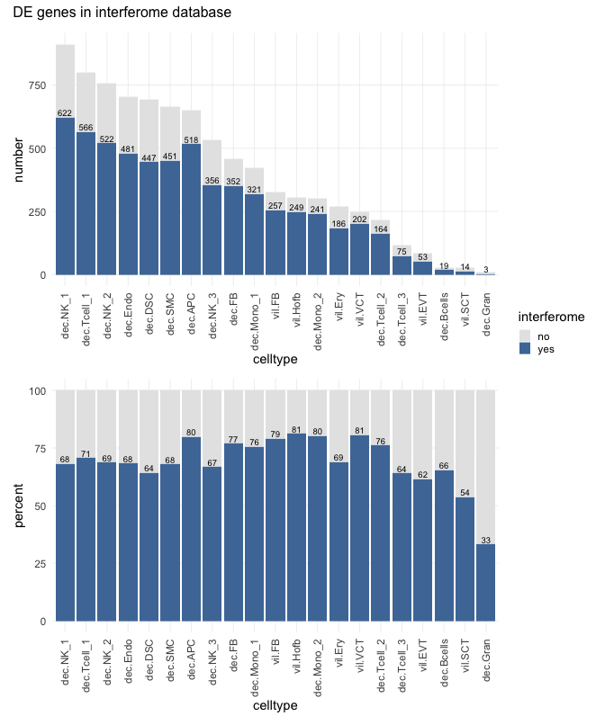

```r
# plot iterferome output
p.n <- ggplot(data = ifome.n.long, aes(x = celltype, y = n)) +
  geom_bar(position = "stack", stat = "identity", aes(fill = interferome)) +
  scale_fill_manual(values = c("grey90", "#4e79a7"), breaks = c("no", "yes")) +
  geom_text(data = ifome.n.long[ifome.n.long$interferome == "yes", ],
            aes(x = celltype, y = n, label = n),
            size = 2.5, vjust = -0.25) +
  labs(y = "number")

p.pct <- ggplot(data = ifome.n.long, aes(x = celltype, y = pct)) +
  geom_bar(position = "stack", stat = "identity", aes(fill = interferome)) +
  scale_fill_manual(values = c("grey90", "#4e79a7"), breaks = c("no", "yes")) +
  geom_text(data = ifome.n.long[ifome.n.long$interferome == "yes", ],
            aes(x = celltype, y = pct, label = round(pct, 0)),
            size = 2.5, vjust = -0.25) +
  labs(y = "percent")

p <- p.n + p.pct + plot_layout(guides = "collect", ncol = 1) +
  plot_annotation(title = "DE genes in interferome database") &
  theme_minimal() +
  theme(plot.title = element_text(size = 12),
        panel.grid.minor = element_blank(),
        panel.grid.major = element_line(size = 0.25),
        legend.key.size = unit(0.75, "lines"),
        axis.text.x = element_text(angle = 90, hjust = 1, vjust = 0.5))

ggsave(p,
       filename = "../results/04_de-genes-by-celltype/interferome/plots/de-genes-interferome.pdf",
       width = 6, height = 8, units = "in")

print(p)
```

For most cell types, a large chunk of genes differentially expressed between covid and control are in fact known to be responsive to interferons according to Interferome. This number is over 60% for most cell types, and approximately 80% for dec.APC, dec.FB, dec.Mono_1, dec.Mono_2, vil.FB, vil.Hofb, vil.VCT, and dec.Tcell_2. It is below 60% only for vil.SCT and dec.Gran, but these cell types have the least number of DE genes, 26 and 9 respectively.

# 5 GO enrichment

I also ran GO enrichment (only for the Biological Process category) for DE genes (only those that are up-regulated in covid) in all celltypes. The table outputs for all celltypes are saved as `.csv` in `results/04_de-genes-by-celltype/files`.

For most cell types, the enriched GO categproes include those related to defense to viral infection, interferon response genes, misfolded protein response, etc. See below for the top 10 enriched GO categories for DE genes in each celltype.

```r
# function for GO enrichment on upregulated genes for each cell type
enrichGO2 <- function(celltype, ...) {

  up <- de.genes[[celltype]] %>%
    dplyr::filter(avg_logFC > 0)

  ids.bitr <- bitr(rownames(up),
                   fromType = "SYMBOL", toType = c("ENTREZID", "SYMBOL"),
                   OrgDb = "org.Hs.eg.db")

  features <- ids.bitr$ENTREZID

  ego <- enrichGO(
    gene          = features,
    OrgDb         = org.Hs.eg.db,
    ont           = "BP",
    pAdjustMethod = "BH",
    pvalueCutoff  = 0.01, # default 0.01
    qvalueCutoff  = 0.05, # default 0.05
    readable = TRUE,
    ...)

  dftoprint <- clusterProfiler::simplify(ego)@result
  rownames(dftoprint) <- NULL

  return(dftoprint)
}
```

```r
# perform GO enrichment
de.go <- list()

for(i in names(de.genes)) {
  de.go[[i]] <- enrichGO2(celltype = i)
}
```

[output not shown]

```r
# write GO enrichments to files
for(i in unique(names(de.go))) {
  write.csv(de.go[[i]],
            file = paste0("../results/04_de-genes-by-celltype/files/enrichedGO_", i, ".csv" ),
            row.names = FALSE)
}
```

```r
for(i in names(de.go)) {
  print(i)
  print(as.data.frame(de.go[[i]][1:10, 2]))
}
```

```
[1] "dec.DSC"
```

| de.go[[i]][1:10, 2] |
| --- |
| protein targeting to ER |
| establishment of protein localization to endoplasmic reticulum |
| nuclear-transcribed mRNA catabolic process, nonsense-mediated decay |
| translational initiation |
| viral transcription |
| viral gene expression |
| protein folding |
| response to unfolded protein |
| oxidative phosphorylation |
| viral life cycle |

```
[1] "dec.SMC"
```

| de.go[[i]][1:10, 2] |
| --- |
| protein localization to endoplasmic reticulum |
| protein targeting to ER |
| translational initiation |
| nuclear-transcribed mRNA catabolic process, nonsense-mediated decay |
| viral transcription |
| viral gene expression |
| protein folding |
| response to unfolded protein |
| viral life cycle |
| oxidative phosphorylation |

```
[1] "dec.APC"
```

| de.go[[i]][1:10, 2] |
| --- |
| neutrophil activation |
| neutrophil mediated immunity |
| neutrophil degranulation |
| neutrophil activation involved in immune response |
| response to interferon-gamma |
| response to molecule of bacterial origin |
| cellular response to biotic stimulus |
| response to unfolded protein |
| T cell activation |
| cellular response to interleukin-1 |

```
[1] "vil.FB"
```

| de.go[[i]][1:10, 2] |
| --- |
| response to unfolded protein |
| type I interferon signaling pathway |
| cellular response to type I interferon |
| regulation of viral genome replication |
| defense response to virus |
| regulation of ossification |
| aging |
| ossification |
| cellular response to unfolded protein |
| regulation of hemopoiesis |

```
[1] "dec.Endo"
```

| de.go[[i]][1:10, 2] |
| --- |
| protein targeting to ER |
| protein localization to endoplasmic reticulum |
| establishment of protein localization to endoplasmic reticulum |
| translational initiation |
| nuclear-transcribed mRNA catabolic process, nonsense-mediated decay |
| viral transcription |
| viral gene expression |
| protein folding |
| response to unfolded protein |
| viral life cycle |

```
[1] "vil.Hofb"
```

| de.go[[i]][1:10, 2] |
| --- |
| response to interferon-gamma |
| type I interferon signaling pathway |
| defense response to virus |
| response to virus |
| regulation of viral genome replication |
| neutrophil activation |
| viral genome replication |
| antigen processing and presentation |
| adaptive immune response based on somatic recombination of immune receptors built from immunoglobulin superfamily domains |
| regulation of adaptive immune response based on somatic recombination of immune receptors built from immunoglobulin superfamily domains |

```
[1] "dec.NK_1"
```

| de.go[[i]][1:10, 2] |
| --- |
| nuclear-transcribed mRNA catabolic process, nonsense-mediated decay |
| protein targeting to ER |
| establishment of protein localization to endoplasmic reticulum |
| translational initiation |
| viral transcription |
| viral gene expression |
| T cell activation |
| response to virus |
| ribonucleoprotein complex biogenesis |
| leukocyte cell-cell adhesion |

```
[1] "vil.EVT"
```

| de.go[[i]][1:10, 2] |
| --- |
| negative regulation of response to endoplasmic reticulum stress |
| rhythmic process |
| regulation of erythrocyte differentiation |
| circadian regulation of gene expression |
| regulation of PERK-mediated unfolded protein response |
| positive regulation of hemopoiesis |
| negative regulation of endoplasmic reticulum unfolded protein response |
| ER overload response |
| regulation of protein ubiquitination |
| intracellular mRNA localization |

```
[1] "dec.FB"
```

| de.go[[i]][1:10, 2] |
| --- |
| response to unfolded protein |
| RNA splicing |
| cellular response to unfolded protein |
| 'de novo' protein folding |
| regulation of RNA splicing |
| RNA localization |
| cellular response to chemical stress |
| type I interferon signaling pathway |
| cellular response to type I interferon |
| viral life cycle |

```
[1] "vil.VCT"
```

| de.go[[i]][1:10, 2] |
| --- |
| response to unfolded protein |
| response to topologically incorrect protein |
| cellular response to unfolded protein |
| regulation of mRNA metabolic process |
| regulation of apoptotic signaling pathway |
| protein folding |
| response to endoplasmic reticulum stress |
| response to calcium ion |
| response to temperature stimulus |
| endoplasmic reticulum unfolded protein response |

```
[1] "dec.Tcell_1"
```

| de.go[[i]][1:10, 2] |
| --- |
| mRNA catabolic process |
| protein targeting to ER |
| translational initiation |
| establishment of protein localization to endoplasmic reticulum |
| viral transcription |
| viral gene expression |
| T cell activation |
| response to virus |
| RNA splicing, via transesterification reactions with bulged adenosine as nucleophile |
| interleukin-12-mediated signaling pathway |

```
[1] "dec.Mono_1"
```

| de.go[[i]][1:10, 2] |
| --- |
| defense response to virus |
| response to virus |
| regulation of viral genome replication |
| type I interferon signaling pathway |
| cellular response to type I interferon |
| viral genome replication |
| response to interferon-alpha |
| cellular response to lipopolysaccharide |
| I-kappaB kinase/NF-kappaB signaling |
| regulation of response to biotic stimulus |

```
[1] "dec.Tcell_2"
```

| de.go[[i]][1:10, 2] |
| --- |
| RNA catabolic process |
| nuclear-transcribed mRNA catabolic process |
| translational initiation |
| SRP-dependent cotranslational protein targeting to membrane |
| establishment of protein localization to endoplasmic reticulum |
| viral transcription |
| viral gene expression |
| viral genome replication |
| 'de novo' protein folding |
| regulation of viral genome replication |

```
[1] "dec.NK_2"
```

| de.go[[i]][1:10, 2] |
| --- |
| protein targeting to ER |
| nuclear-transcribed mRNA catabolic process, nonsense-mediated decay |
| translational initiation |
| establishment of protein localization to endoplasmic reticulum |
| viral gene expression |
| viral transcription |
| ribonucleoprotein complex biogenesis |
| response to virus |
| ribosome assembly |
| T cell activation |

```
[1] "dec.Bcells"
```

| de.go[[i]][1:10, 2] |
| --- |
| SRP-dependent cotranslational protein targeting to membrane |
| cotranslational protein targeting to membrane |
| protein targeting to ER |
| nuclear-transcribed mRNA catabolic process, nonsense-mediated decay |
| establishment of protein localization to endoplasmic reticulum |
| viral transcription |
| viral gene expression |
| translational initiation |
| ribosomal small subunit biogenesis |
| NA |

```
[1] "vil.Ery"
```

| de.go[[i]][1:10, 2] |
| --- |
| bicarbonate transport |
| gas transport |
| erythrocyte differentiation |
| erythrocyte homeostasis |
| porphyrin-containing compound metabolic process |
| hemoglobin metabolic process |
| porphyrin-containing compound biosynthetic process |
| iron ion homeostasis |
| hydrogen peroxide catabolic process |
| cofactor metabolic process |

```
[1] "dec.NK_3"
```

| de.go[[i]][1:10, 2] |
| --- |
| protein targeting to ER |
| establishment of protein localization to endoplasmic reticulum |
| mRNA catabolic process |
| RNA catabolic process |
| viral transcription |
| translational initiation |
| viral gene expression |
| protein folding |
| oxidative phosphorylation |
| cell killing |

```
[1] "dec.Tcell_3"
```

| de.go[[i]][1:10, 2] |
| --- |
| NA |
| NA |
| NA |
| NA |
| NA |
| NA |
| NA |
| NA |
| NA |
| NA |

```
[1] "dec.Mono_2"
```

| de.go[[i]][1:10, 2] |
| --- |
| response to virus |
| type I interferon signaling pathway |
| cellular response to type I interferon |
| defense response to virus |
| positive regulation of cytokine production |
| cellular response to biotic stimulus |
| neutrophil activation |
| response to molecule of bacterial origin |
| neutrophil mediated immunity |
| T cell activation |

```
[1] "dec.Gran"
```

| de.go[[i]][1:10, 2] |
| --- |
| NA |
| NA |
| NA |
| NA |
| NA |
| NA |
| NA |
| NA |
| NA |
| NA |

```
[1] "vil.SCT"
```

| de.go[[i]][1:10, 2] |
| --- |
| response to unfolded protein |
| response to heat |
| response to topologically incorrect protein |
| regulation of cellular response to heat |
| regulation of protein ubiquitination |
| protein folding |
| negative regulation of inclusion body assembly |
| regulation of tau-protein kinase activity |
| chaperone-mediated protein complex assembly |
| regulation of mitotic spindle assembly |

# 6 Volcano plots

Below are volcano plots for all cell types: -log10(p value) vs logFC; top 30 genes with highest `abs(logFC)` are labeled.

```r
# function for volcano plot
de_volcano <- function(celltype) {

  plot.dat <- de.genes[[celltype]]
  plot.dat$gene <- rownames(plot.dat)

  # top DE genes
  genes.to.label = de.genes[[celltype]] %>%
    .[order(abs(de.genes[[celltype]]$avg_logFC), decreasing = TRUE), ] %>%
    rownames() %>% .[1:30]

  plot.dat$label <- ifelse(test = plot.dat$gene %in% genes.to.label,
                           yes = plot.dat$gene,
                           no = NA)

  p <- ggplot(plot.dat,
              aes(avg_logFC, -log10(p_val_adj), label = label)) +
    geom_point(alpha = 0.4, size = 2) +
    ggtitle(celltype) +
    geom_label_repel(size = 3, force = 1, color = "grey20") +
    theme_bw() +
    theme(panel.grid.major = element_line(size = 0.25),
          panel.grid.minor = element_blank())

  return(p)
}
```

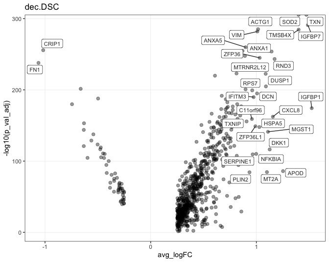

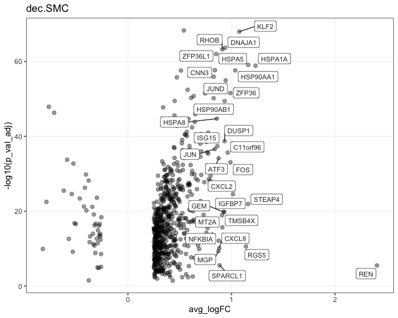

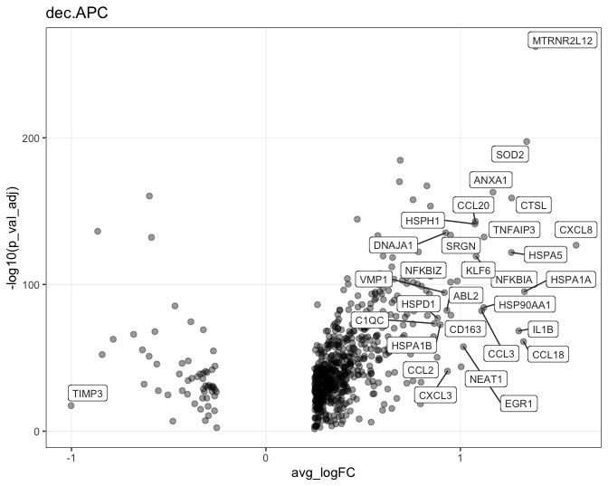

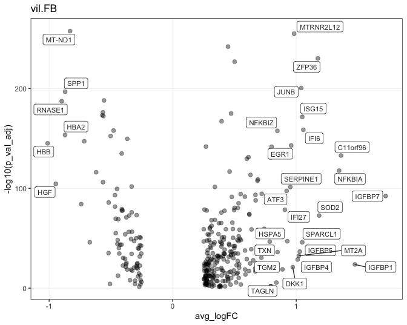

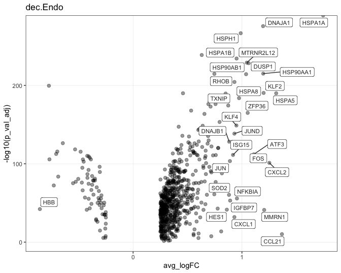

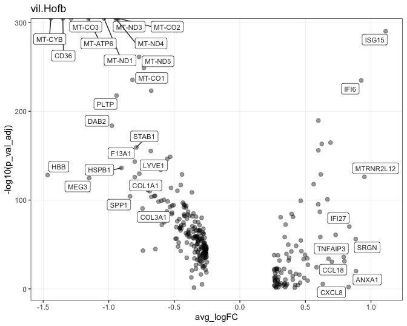

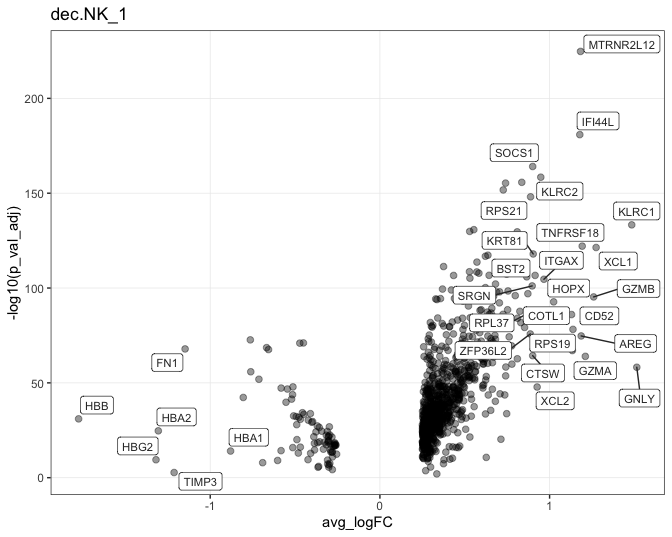

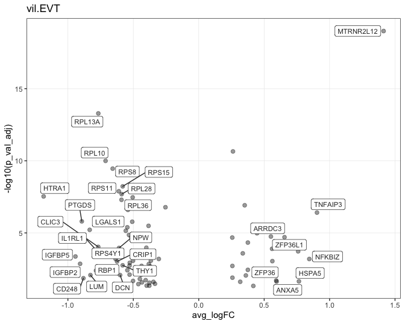

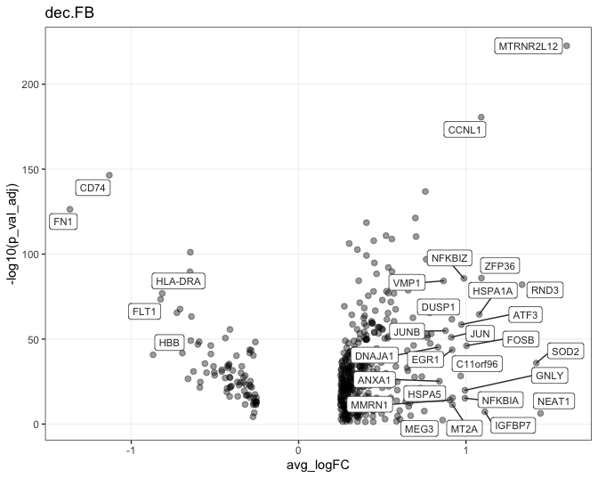

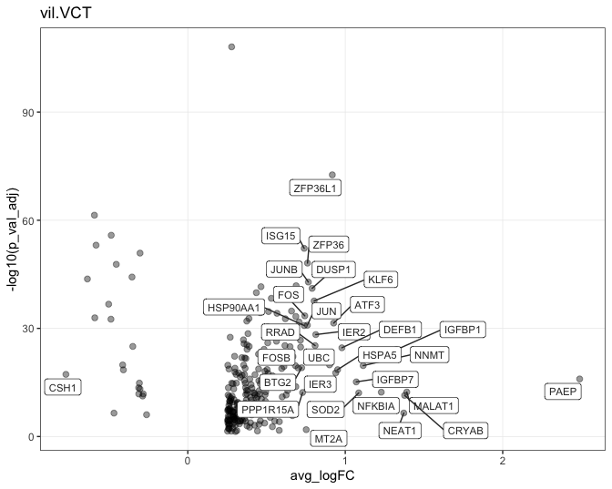

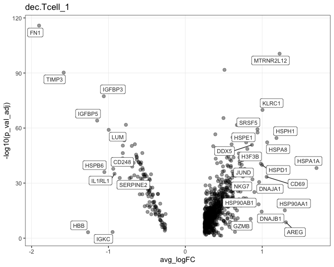

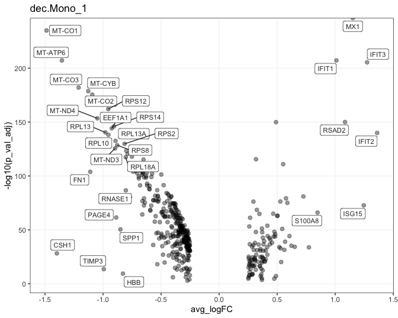

[9 more figures not shown]

```r
for(i in names(de.genes)) {
  p <- de_volcano(celltype = i)

  ggsave(p,
         filename = paste0("../results/04_de-genes-by-celltype/plots/volcanoplot_", i, ".pdf"),
         width = 7, height = 5.5, units = "in")

  print(p)
}
```

# 7 Labor signature

The control samples in our data come from C-sections. Which makes this a confounding factor in our analyeses. In order to address this, we can compare the list of DE genes between covid and control samples with the list of DE genes between term in labor (TIL) and term not in labor (TNL). This can tell us if (and how much) part of our DE results are driven by labor rather than covid status.

The TIL vs TNL differential gene expression results from (Pique-Regi et al. 2019) can be used for this. I downloaded the supplementary file. The file is described as follows: “The columns represent: 1) Cluster or cell-type name, 2) Comparison groups or contrast (i.e., TNL vs TIL, TIL vs PTL), 3) Ensembl gene identifier, 4) Gene symbol, 5) baseMean gene baseline expression as calculated by DESeq2, 6) log2 Fold Change of the first group in column two versus the second group, 7) Standard error estimated for the log2 Fold Change, 8) Nominal p-value, 9) q-value or adjusted p-value to control for FDR. Only rows with q < 0.2 are reported.”.

```r
til <- readxl::read_excel("../info/from-papers/pique-regi_2019/supp/elife-52004-supp5-v2.xls")
labor <- til %>% filter(Compare == "TNL_v_TIL" & padj < 0.05)
head(labor)
```

| Cluster | Compare | ENSG | Gene | baseMean | log2FoldChange | lfcSE | stat | pvalue | padj |
| --- | --- | --- | --- | --- | --- | --- | --- | --- | --- |
| npiCTB | TNL_v_TIL | ENSG00000251562 | MALAT1 | 338.20093 | -1.938555 | 0.3812881 | -5.084226 | 3.691288e-07 | 0.002754439 |
| CTB | TNL_v_TIL | ENSG00000117594 | HSD11B1 | 42.43027 | -4.332350 | 0.9075875 | -4.773479 | 1.810700e-06 | 0.006313459 |
| CTB | TNL_v_TIL | ENSG00000115602 | IL1RL1 | 65.17839 | -3.944675 | 0.8352454 | -4.722774 | 2.326491e-06 | 0.006489513 |
| CTB | TNL_v_TIL | ENSG00000115461 | IGFBP5 | 49.48677 | -2.699464 | 0.6676648 | -4.043142 | 5.273973e-05 | 0.049818081 |
| CTB | TNL_v_TIL | ENSG00000273125 | RP11-115H18.1 | 374.46126 | 1.907581 | 0.4099453 | 4.653258 | 3.267314e-06 | 0.007594872 |
| CTB | TNL_v_TIL | ENSG00000128510 | CPA4 | 108.55075 | 1.489293 | 0.3691211 | 4.034700 | 5.467212e-05 | 0.049818081 |

Now we have to find out how many of the DE genes between TNL and TIL are shared with DE genes between covid and control.

```r
# all DE genes across all cell types between covid and control
de.all <- de.genes

for(i in names(de.all)) {
  de.all[[i]]$gene <- rownames(de.all[[i]])
}

de.all <- do.call(rbind, de.all)

de.all.genes <- de.all$gene %>% unique()

# all labor DE genes
labor.genes <- labor$Gene %>% unique()
```

```r
# number of covid vs control DE genes (across all cell types)
length(de.all.genes)
```

```
[1] 2420
```

```r
# number of TNL vs TIL DE genes (across all cell types)
length(labor.genes)
```

```
[1] 195
```

```r
# number of DE genes shared between covid vs control and TNL vs TIL
length(intersect(de.all.genes, labor.genes))
```

```
[1] 110
```

There are 110 genes that are shared between covid vs control and TNL vs TIL. These are likely related to labor. These genes are as follows:

```r
intersect(de.all.genes, labor.genes) %>% sort()
```

```
  [1] "ABCA1"     "ACTB"      "AHNAK"     "AHR"       "AKAP13"    "ANXA1"
  [7] "ARL4C"     "B4GALT1"   "BIRC3"     "C1QA"      "C1QB"      "C1QC"
 [13] "CA2"       "CAMK1"     "CCL18"     "CCND2"     "CCNL1"     "CD163"
 [19] "CD2"       "CD248"     "CD3E"      "CD55"      "CDKN2A"    "CFLAR"
 [25] "CKLF"      "CLDN5"     "CLEC4E"    "CXCL1"     "CYTH1"     "DEFB1"
 [31] "DNAJA4"    "ELF1"      "ELF3"      "EMP1"      "ETS2"      "FABP5"
 [37] "FCGR2B"    "FGL2"      "FILIP1L"   "FNBP1"     "FNIP2"     "FOSB"
 [43] "GNLY"      "GPCPD1"    "GPR132"    "HIST1H2BG" "HLA-DPB1"  "HLA-DRB5"
 [49] "HSD11B1"   "HSPA6"     "ICAM1"     "ID2"       "IDH2"      "IFI27"
 [55] "IFITM2"    "IFITM3"    "IGFBP1"    "IGFBP2"    "IGFBP4"    "IGFBP5"
 [61] "IL1RL1"    "ITGB3BP"   "IVNS1ABP"  "JUND"      "KCNQ1OT1"  "KDM6B"
 [67] "KLF6"      "LDHB"      "LILRB5"    "LMNA"      "LSP1"      "MAFF"
 [73] "MALAT1"    "MBNL1"     "MGST1"     "MMP19"     "NAMPT"     "NEAT1"
 [79] "NFAT5"     "NFKB1"     "NFKBIA"    "OLFML3"    "PAPSS2"    "PDE4B"
 [85] "PLAC8"     "PNRC1"     "POU2F2"    "PTGDS"     "RASGEF1B"  "RCAN1"
 [91] "RGCC"      "RPS26"     "SAMSN1"    "SDC4"      "SERPINE1"  "SOD2"
 [97] "SPP1"      "SRGN"      "SRSF5"     "STAB1"     "TFPI"      "TIPARP"
[103] "TNFAIP2"   "TNFAIP3"   "TRAT1"     "TXN"       "TYMS"      "UBE2D1"
[109] "VEGFA"     "ZFP36"
```

Now we can compare whether the shared genes change in the same direction that we expect based on the information that our control samples come from C-sections.

```r
# create a dataframe of shared genes and their direction of changes
shared <- data.frame(
  gene = intersect(de.all.genes, labor.genes) %>% sort()
)

shared$labor_logfc <- NA
for(i in 1:nrow(shared)){
  shared$labor_logfc[i] <- mean(labor$log2FoldChange[labor$Gene == shared$gene[i]])
} # because the same gene can be DE in multiple cell types, we have to take average logFC. Not the best option, but quick and dirty.

shared$covid_logfc <- NA
for(i in 1:nrow(shared)){
  shared$covid_logfc[i] <- mean(de.all$avg_logFC[de.all$gene == shared$gene[i]])
}

shared$labor_pattern[shared$labor_logfc < 0] <- "TIL_high"
shared$labor_pattern[shared$labor_logfc > 0] <- "TNL_high"

shared$covid_pattern[shared$covid_logfc < 0] <- "control_high"
shared$covid_pattern[shared$covid_logfc > 0] <- "covid_high"
```

The contigency table of shared DE genes looks like this:

```r
table(shared$labor_pattern, shared$covid_pattern)
```

```
           control_high covid_high
  TIL_high           13         74
  TNL_high            6         17
```

Or in terms of proportions, like this:

```r
table(shared$labor_pattern, shared$covid_pattern) %>% prop.table()
```

```
           control_high covid_high
  TIL_high   0.11818182 0.67272727
  TNL_high   0.05454545 0.15454545
```

Fisher’s exact test for this contingency table looks like this:

```r
table(shared$labor_pattern, shared$covid_pattern) %>% fisher.test(alternative = "two.sided")
```

```
    Fisher's Exact Test for Count Data

data:  .
p-value = 0.2233
alternative hypothesis: true odds ratio is not equal to 1
95 percent confidence interval:
 0.1495445 1.8458468
sample estimates:
odds ratio
 0.5013382
```

# 9 References

Pique-Regi, R., R. Romero, A. L. Tarca, E. D. Sendler, Y. Xu, V. Garcia-Flores, Y. Leng, F. Luca, S. S. Hassan, and N. Gomez-Lopez. 2019. “Single Cell Transcriptional Signatures of the Human Placenta in Term and Preterm Parturition.” *eLife* 8: e52004.

Rusinova, I., S. Forster, S. Yu, A. Kannan, M. Masse, H. Cumming, R. Chapman, and P. J. Hertzog. 2012. “INTERFEROME v2.0: an updated database of annotated interferon-regulated genes.” *Nucleic Acids Research* 41 (D1): D1040–D1046. https://doi.org/10.1093/nar/gks1215.